# Issues and Improvement

Ankit

4/16/2019

Higher frequency time series like daily level, hourly level time series can exhibit very complicated seasonal patterns. For eg. daily level data can have weekly seasonality and annual seasonality as well.

Also for weekly data the frequency is in decimals 52.179 (approx). Most of the methods only allows for integer seasonality and also only one level of seasonality. We may not always wants to include all the levels of seasonality but sometimes it is very important to handle different seasonality in the data.

**Example** Calls data shows the number of retail banking call arrivals per 5-minute interval between 7:00am and 9:05pm each weekday over a 33 week period. Now this data has 2 levels of seasonality that we will explore.

```r
library(fpp2)
```

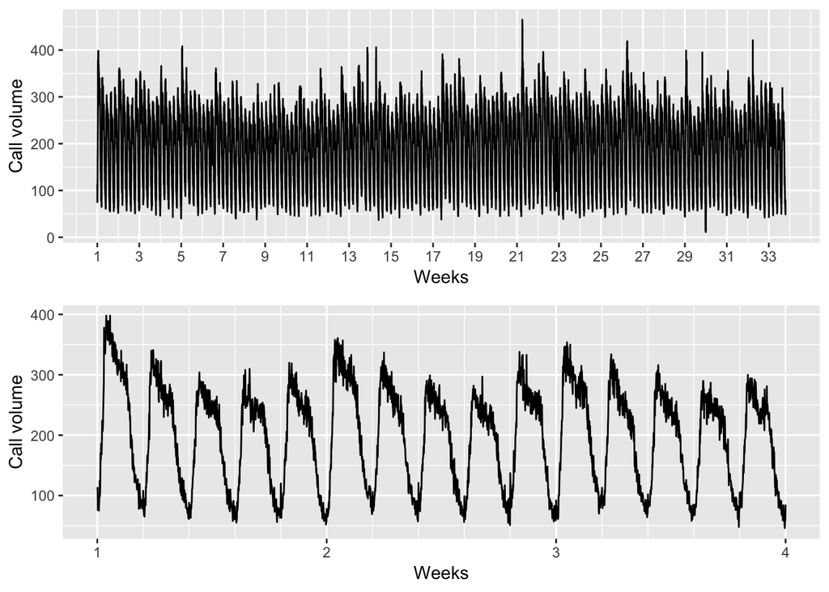

```r
p1 = autoplot(calls) +
  ylab("Call volume") + xlab("Weeks") +
  scale_x_continuous(breaks = seq(1,33, by = 2))
p2 = autoplot(window(calls, end = 4)) +
  ylab("Call volume") + xlab("Weeks") +
  scale_x_continuous(minor_breaks = seq(1,4, by = 0.2))
gridExtra::grid.arrange(p1,p2)
```

The above 2 graphs shows that there are 2 seasonality present in the data. We have daily seasonal pattern as can be seen in the 2nd graph, the mondays usually have higher no. of calls.

Another way to look at multiple seasonality is by decomposing the time series. We can use mstl() function for that.

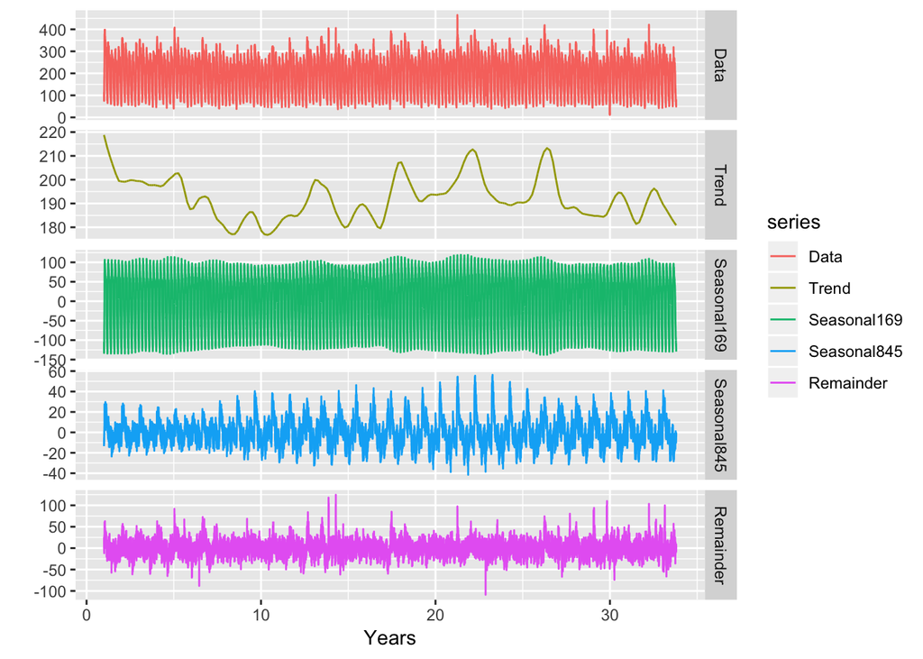

```r
calls %>% mstl() %>%
  autoplot(calls) + xlab("Years")
```

The above do not show any consistent trend. We have a daily seasonal data in the third panel and weekly seasonal pattern in the fourth panel. The scales of weekly seasonality has narrow range than daily seasonality. We can use decomposition for forecasting as well.

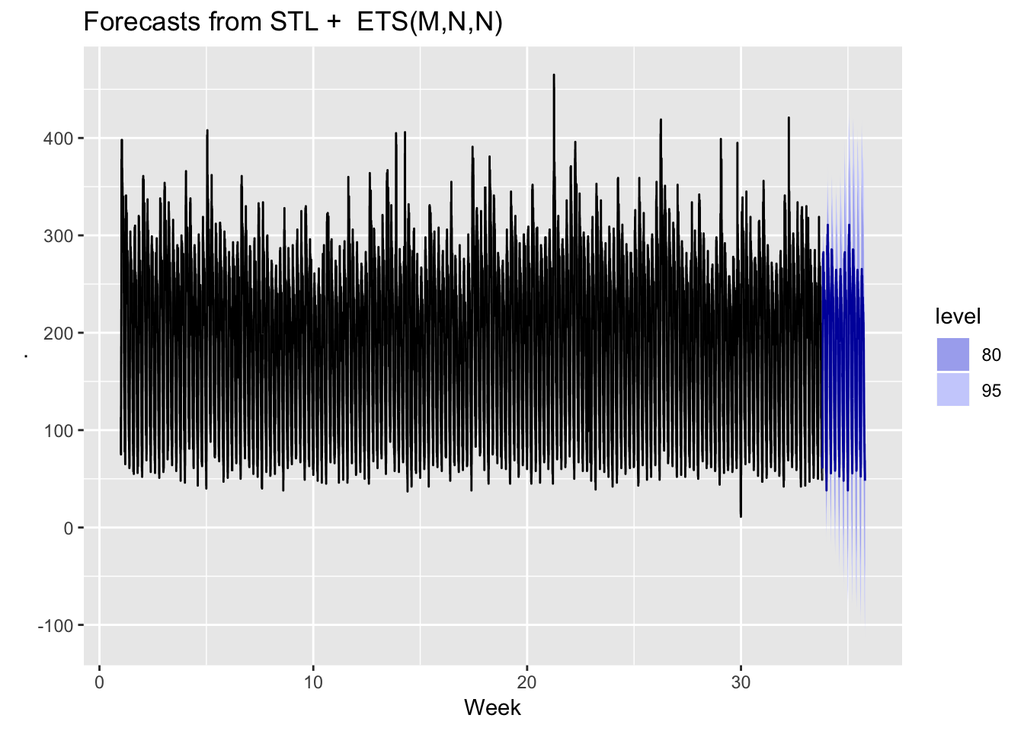

```r
calls %>% stlf() %>%
  autoplot() + xlab("Week")
```

**Dynamic Harmonic Regression Models**

Another way to deal with it is to use dynamic harmonic regression model. Since we have 2 types of seaonalities we have to add fourier terms to handle both the seasonalities. Our seasonal frequencies are 169 and 845, so we need to add $sin(\frac{2\pi kt}{169})$, $cos(\frac{2\pi kt}{169})$, $sin(\frac{2\pi kt}{845})$ and $cos(\frac{2\pi kt}{845})$, for k = 1,2,…

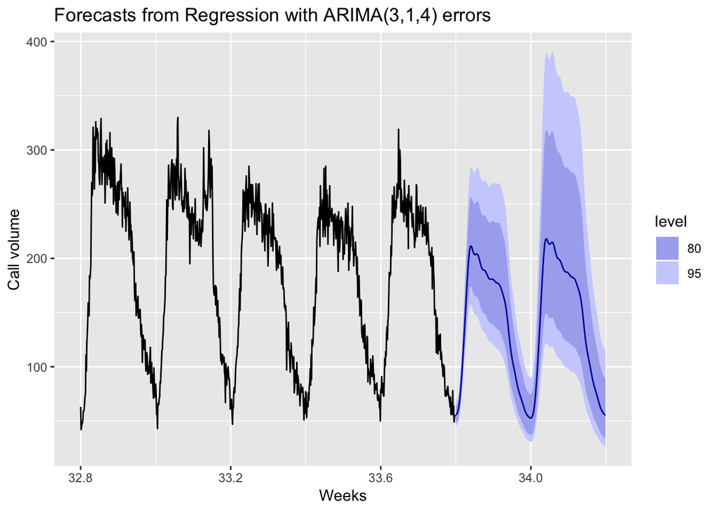

```r
fit <- auto.arima(calls, seasonal=FALSE, lambda=0,
         xreg=fourier(calls, K=c(10,10)))
fit %>%
  forecast(xreg=fourier(calls, K=c(10,10), h=2*169)) %>%
  autoplot(include=5*169) +
    ylab("Call volume") + xlab("Weeks")
```

**TBATS Models**

Another approach for this problem is to fit TBATS Models(Trigonometric seasonality, Box-Cox Transformation, ARIMA Errors, Trend and seasonlaity). This uses a combination of Fourier terms with an exponential state space model and Box-Cox transformation. This technique is different from dynamic harmonic regression in that seasonality is allowed to change over time.

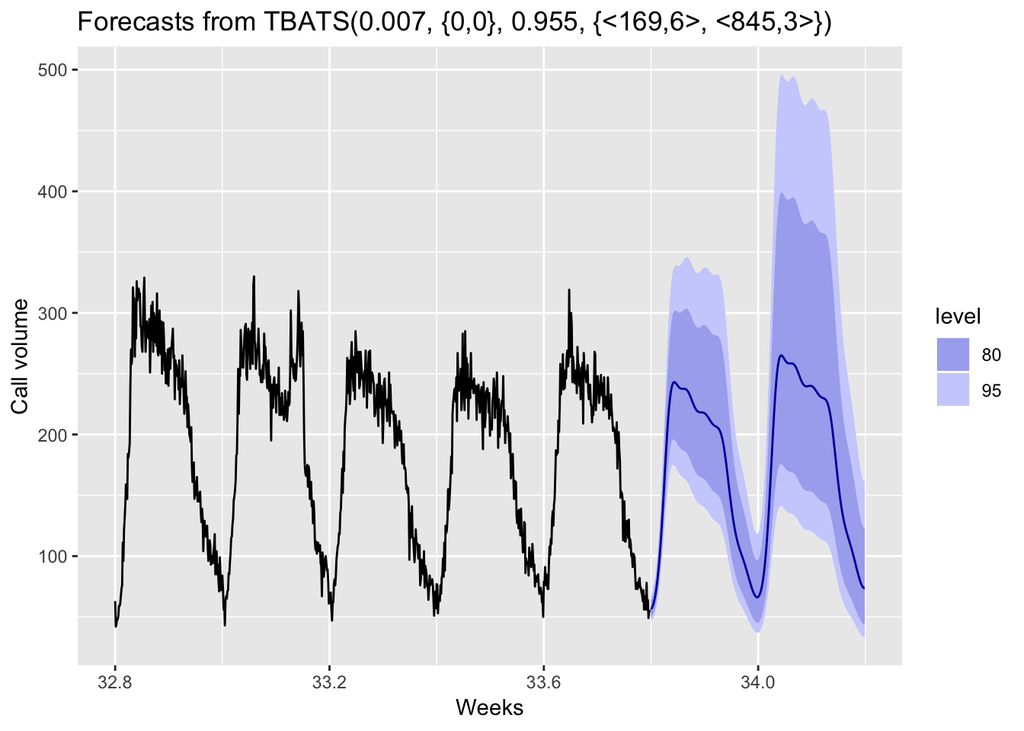

```r
calls %>%
  subset(start = length(calls) - 2000) %>%
  tbats() -> fit2
fc2 = forecast(fit2, h = 2*169)
autoplot(fc2, include = 5*169) +
  ylab("Call volume") + xlab("Weeks")
```

One drawback of tbats model is that they are slow to estimate if time series is long. Here the prediction intervals appear to be much too wide – something that seems to happen quite often with TBATS models unfortunately.

Also, TBATS models do not allow for covariates but they can be allowed in dynamic harmonic regression model.

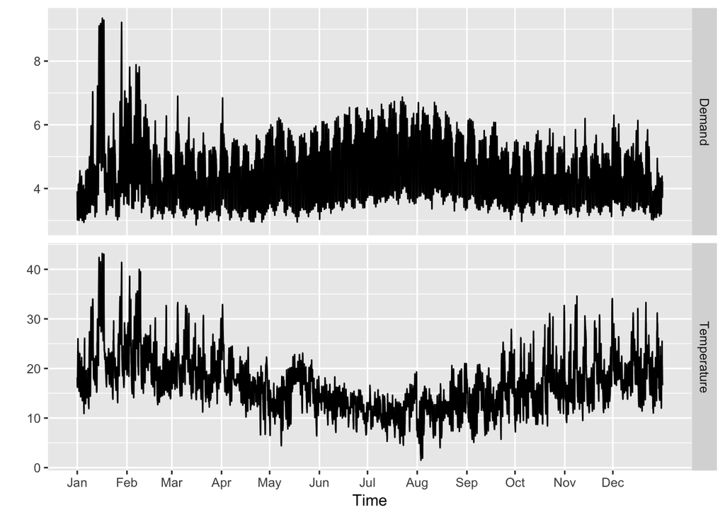

```r
autoplot(elecdemand[,c("Demand","Temperature")],
    facet=TRUE) +
  scale_x_continuous(minor_breaks=NULL,
    breaks=2014+
      cumsum(c(0,31,28,31,30,31,30,31,31,30,31,30))/365,
    labels=month.abb) +
  xlab("Time") + ylab("")
```

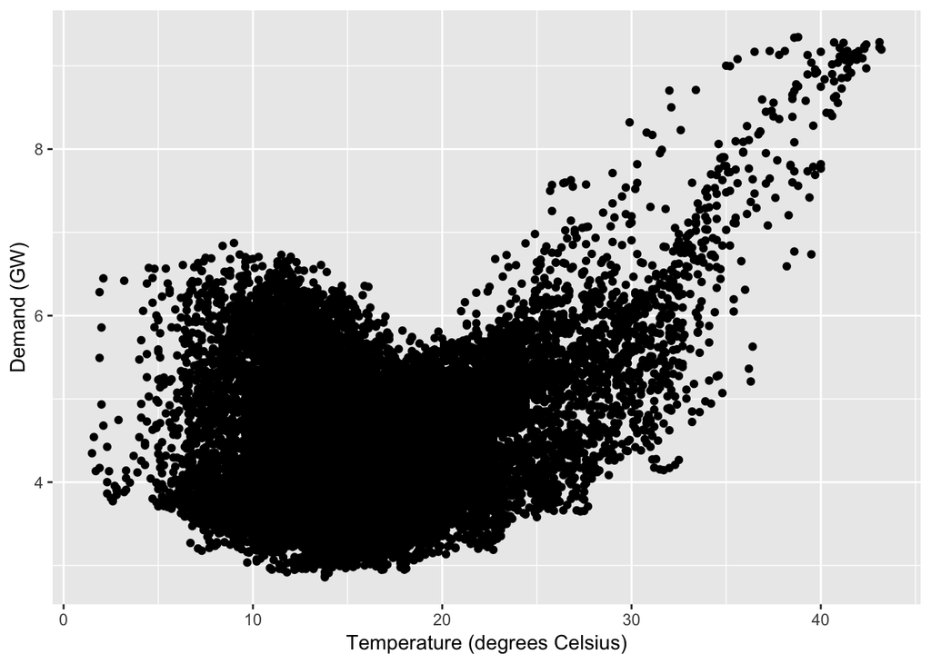

```r
elecdemand %>%
  as.data.frame() %>%
  ggplot(aes(x=Temperature, y=Demand)) + geom_point() +
    xlab("Temperature (degrees Celsius)") +
    ylab("Demand (GW)")
```

Since the relationship is non-linear, we will fit a piecewise linear function with knot at 18 and harmonic regression term to allow for daily seasonality.

```r
cooling <- pmax(elecdemand[,"Temperature"], 18)
fit <- auto.arima(elecdemand[,"Demand"],
         xreg = cbind(fourier(elecdemand, c(10,10,0)),
               heating=elecdemand[,"Temperature"],
               cooling=cooling))
```

Forecast from the model.

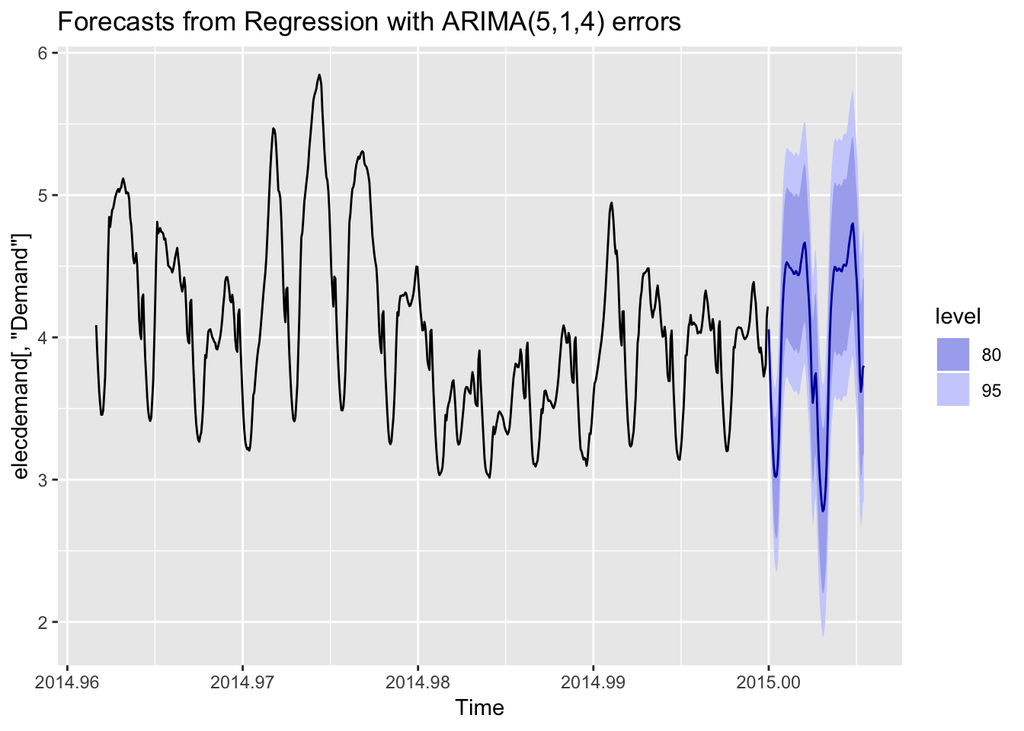

```r
temps <- subset(elecdemand[,"Temperature"],
          start=NROW(elecdemand)-2*48+1)
fc <- forecast(fit,
        xreg=cbind(fourier(temps, c(10,10,0)),
          heating=temps, cooling=pmax(temps,18)))
autoplot(fc, include=14*48)
```

Although the short-term forecasts look reasonable, this is a crude model for a complicated process. The residuals demonstrate that there is a lot of information that has not been captured with this model.

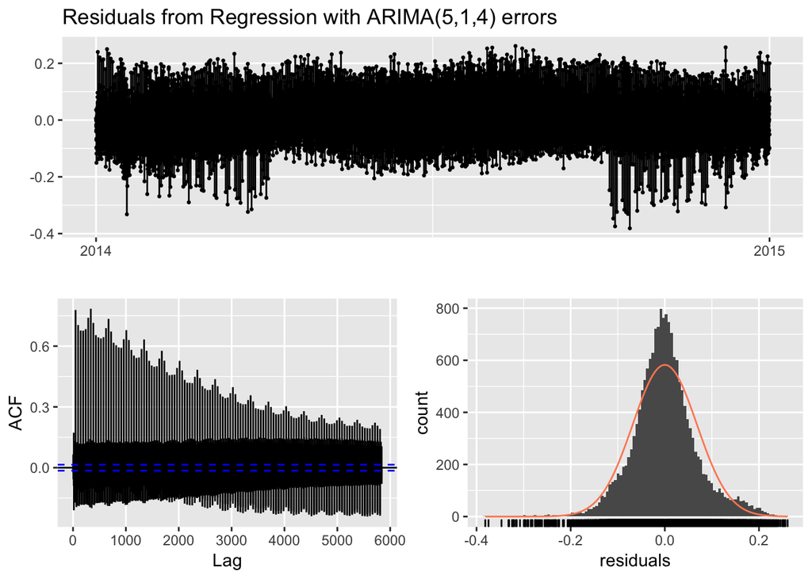

```
##
##  Ljung-Box test
##
## data:  Residuals from Regression with ARIMA(5,1,4) errors
## Q* = 738300, df = 3455, p-value < 2.2e-16
##
## Model df: 49.   Total lags used: 3504
```

```r
checkresiduals(fc)
```